# Excess rentals in TfL bike sharing

2021-09-30

# Challenge 1: Excess rentals in TfL bike sharing

Recall the TfL data on how many bikes were hired every single day. We can get the latest data by running the following

```r
url <- "https://data.london.gov.uk/download/number-bicycle-hires/ac29363e-e0cb-47cc-a97a-e216d900a6b0/tfl-daily-cycle-hires.xlsx"

# Download TFL data to temporary file
httr::GET(url, write_disk(bike.temp <- tempfile(fileext = ".xlsx")))
```

```
## Response [https://airdrive-secure.s3-eu-west-1.amazonaws.com/london/dataset/number-bicycle-hires/2021-09-23T12%3A52%3A20/tfl-daily-cycle-hires.xlsx?X-Amz-Algorithm=AWS4-HMAC-SHA256&X-Amz-Credential=AKIAJJDIMAIVZJDICKHA%2F20211020%2Feu-west-1%2Fs3%2Faws4_request&X-Amz-Date=20211020T224304Z&X-Amz-E…
##   Date: 2021-10-20 22:45
##   Status: 200
##   Content-Type: application/vnd.openxmlformats-officedocument.spreadsheetml.sheet
##   Size: 174 kB
## <ON DISK>  C:\Users\peter\AppData\Local\Temp\Rtmp2vjguQ\file6140f61e9.xlsx
```

```r
# Use read_excel to read it as dataframe
bike0 <- read_excel(bike.temp,
                   sheet = "Data",
                   range = cell_cols("A:B"))

# change dates to get year, month, and week
bike <- bike0 %>%
  clean_names() %>%
  rename (bikes_hired = number_of_bicycle_hires) %>%
  mutate (year = year(day),
          month = lubridate::month(day, label = TRUE),
          week = isoweek(day))
```

## Look at May and Jun and compare 2020 with the previous years. What’s happening?

However, the challenge I want you to work on is to reproduce the following two graphs.

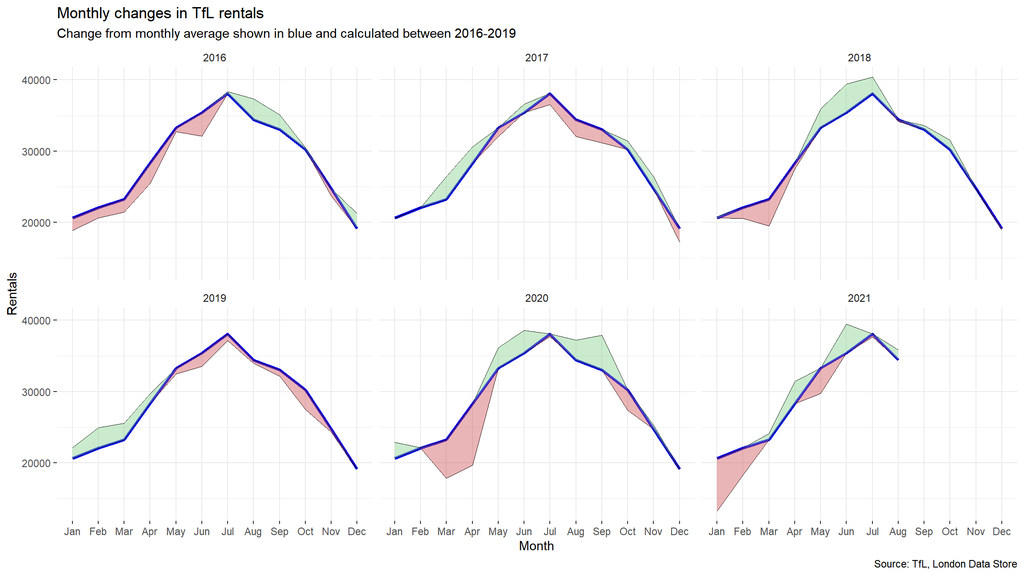

```r
# Create chart here
bike_expected_df <- bike %>%
  filter(day > "2015-12-31", day < "2020-01-01") %>% # calculate mean for 2016-2019 as stated in the chart
  group_by(month) %>% # group by month to calculate monthly mean over the years 2016-2019
  summarise(
    expected_rentals = mean(bikes_hired)
    )

bike_actual_df <- bike %>%
  filter(day > "2015-12-31") %>% # filter for years 2016 to current
  group_by(month, year) %>%  # group by month and year to calculate monthly mean per year
  summarise(
    actual_rentals = mean(bikes_hired)
  ) %>%
  left_join(bike_expected_df, by ="month") %>% # left join previous data frame with expected rentals to the new df with actuals
  mutate(
    excess_bike_rentals = actual_rentals - expected_rentals, # calculate excess rentals over mean
    up = ifelse(actual_rentals>expected_rentals, excess_bike_rentals, 0), # filter deviations above mean
    down = ifelse(actual_rentals<expected_rentals, excess_bike_rentals, 0), # filter devations below mean
    up_plus_expected = expected_rentals + up, # expected + deveation above mean to create chart
    down_plus_expected = expected_rentals + down # expected + deveation below mean to create chart
  )

plot <- bike_actual_df %>%
  ggplot(aes(x = month, y = expected_rentals)) +
  facet_wrap(vars(year)) +
  geom_line(aes(y = expected_rentals), group = 1, color = "blue", lwd = 1.1) +
  geom_line(aes(y = up_plus_expected), group = 1, lwd = 0.1) +
  geom_line(aes(y = down_plus_expected), group = 1, lwd = 0.1) +
  geom_ribbon(aes(ymin = expected_rentals,ymax = expected_rentals + up),fill="#7DCD85",alpha=0.4, group = 1) +
  geom_ribbon(aes(ymin = expected_rentals + down , ymax = expected_rentals),fill="#CB454A",alpha=0.4, group = 1) +
  labs(
    title = "Monthly changes in TfL rentals",
    subtitle = "Change from monthly average shown in blue and calculated between 2016-2019",
    caption = "Source: TfL, London Data Store",
    x = "Month",
    y = "Rentals"
  ) +
  theme_bw() +
  theme(panel.border = element_blank(), # remove border
        strip.background = element_blank() # remove background of headers
        )

plot
```

The second one looks at percentage changes from the expected level of weekly rentals. The two grey shaded rectangles correspond to Q2 (weeks 14-26) and Q4 (weeks 40-52).

Our graph is the one below with labels on both axes!

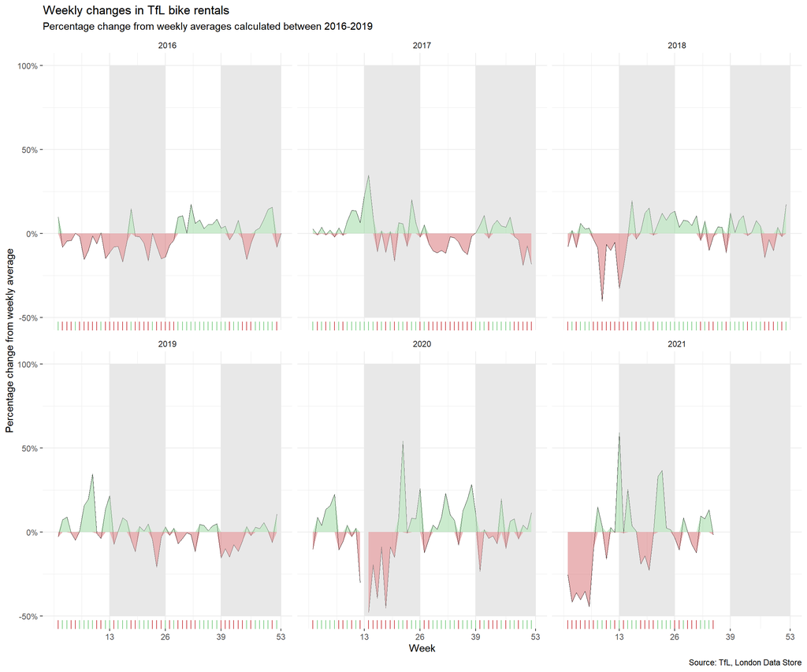

```r
bike_expected_week_df <- bike %>%
  filter(day > "2015-12-31", day < "2020-01-01") %>% # filter for years 2016-2019 to calcualte average
  group_by(week) %>%
  summarise(
    expected_rentals = mean(bikes_hired),
    )

bike_actual_week_df <- bike %>%
  filter(day > "2015-12-31", day <= "2021-08-31") %>% # cut off values beyond August 2021
  group_by(week, year) %>% # group by week and year, just as in the task before
  summarise(
    actual_rentals = mean(bikes_hired)
  ) %>%
  left_join(bike_expected_week_df, by ="week") %>% # join tables with left_join (see above)
  mutate(
    excess_bike_rentals = actual_rentals - expected_rentals,
    percentage = ifelse((year == 2021) & (week > 36), NA, actual_rentals / expected_rentals -1),
    up = ifelse(percentage > 0, percentage, 0),
    down = ifelse(percentage < 0, percentage, 0),
    up_ribbon = ifelse(percentage > 0, percentage, NA), # create extra calculation for ribbons with NA for geom_rug
    down_ribbon = ifelse(percentage < 0, percentage, NA) # create extra calculation for ribbons with NA for geom_rug
  )

q2 <- bike_actual_week_df %>%
  filter(week < 13, week < 27)

q4 <- bike_actual_week_df %>%
  filter(week < 39, week < 53)

#plot
plot <- bike_actual_week_df %>%
  ggplot(aes(x = week, y = percentage)) +
  facet_wrap(vars(year)) +
  geom_line(aes(y = percentage), group = 1, na.rm = FALSE, lwd = 0.1) +
  geom_ribbon(aes(ymin = 0,ymax = up ),fill="#7DCD85",alpha=0.4, group = 1) +
  geom_ribbon(aes(ymin = down , ymax = 0),fill="#CB454A",alpha=0.4, group = 1) +
  geom_rug(aes(y = down_ribbon), position = "stack", color = "#CB454A", sides = "b", na.rm = TRUE, show.legend = NA) + # use position "stack" to make the tick intervals equal
  geom_rug(aes(y = up_ribbon), position = "stack", color = "#7DCD85", sides = "b", na.rm = TRUE, show.legend = NA) + # use position "stack" to make the tick intervals equal
  #geom_rect(data = q2, aes(xmin = 16, xmax = 26, ymin = 0, fill = t), color = "grey") +
  geom_rect(aes(xmin=13, xmax=26, ymin=-0.5, ymax=1), fill="grey", alpha=.01) + # add grey tiles
  geom_rect(aes(xmin=39, xmax=53, ymin=-0.5, ymax=1), fill="grey", alpha=.01) + # add grey tiles
  scale_y_continuous(limits = c(-.5, 1), labels = scales::percent) + # limit scale according to provided image
  scale_x_continuous(limits = c(0, 53), breaks = c(13, 26, 39, 53)) + # adjust breaks to fit example
  theme_bw() +
  theme(panel.border = element_blank(), # remove border
        strip.background = element_blank() # remove header background
        ) +
  labs(title = "Weekly changes in TfL bike rentals",
       subtitle = "Percentage change from weekly averages calculated between 2016-2019",
       caption = "Source: TfL, London Data Store",
       x = "Week",
       y = "Percentage change from weekly average")

plot
```

Should you use the mean or the median to calculate your expected rentals? Why?

If we need to find out the expected value, it always means the long term average or mean. Depending on the distribution and skewness of the data, mean can be a better estimate when the data is left or right skewed, or when the standard deviations can cancel each other off.